```python
import numpy as np
import matplotlib.pyplot as plt
import copy
import time
#import multiprocessing as mp
#import itertools
from scipy.special import loggamma
from scipy.stats import lognorm
from statsmodels.graphics.tsaplots import plot_acf
```

# *Assignment 2*

Welcome to Assignment 2! In this assignment you are allowed to work *individually or in pairs*. It is worth 30 points in total. Exercises 1, 2 and 3 can give you 10 points each. There is a 5 point minimum for passing this assignment (you need to pass all four assignments to be able to pass the course).

Submission details: Your submission should contain two pdf's.

1. A pdf version of your filled out colaboratory on Canvas. You can do this by pressing `cmd/ctrl+p` (you know the drill from there).
2. For exercise 1, you need to hand in your hand-written solutions in a LaTeX pdf. We only accept solutions written in LaTeX, i.e. not Word or any other text editor. We recommend [Overleaf](https://overleaf.com), if you do not already have a favourite LaTeX editor (which is also [provided by KTH](https://intra.kth.se/en/it/programvara-o-system/programvara/installera/download/overleaf/overleaf-1.932755)).

# Contents

In this assignment we will cover the following topics (not necessarily in this order):

- Conjugate Priors
- Gibbs Sampling
- Metropolis-Hastings
- Convergence diagnostics

# *1. Conjugate Priors*

Conjugate distributions are very important and widely used distributions in Bayesian statistics. Having a closed-form expression for the posterior distribution provides great convenience.

It is important to feel confident with derivations and being able to find closed-form expressions. For this task, we give you well-known likelihood functions & prior distributions and ask you to *derive* the closed form expressions of the posterior distributions.

For this exercise, you need to hand in your hand-written solutions in a LaTeX pdf. We only accept solutions written in LaTeX.

**Q1.1 There are $N$ i.i.d. data points sampled from a Normal distribution; $\mathcal{N}(x_i | \mu, \sigma^2)$ for $i \in[N]$ where $\mu$ is the mean and $\sigma^2$ is the variance. Assume $\sigma^2$ is known and the mean has the Normal prior distribution $\mathcal{N}(\mu | \mu_0, \sigma^2)$. Show the posterior distribution of mean is \begin{align*} \mathcal{N} \left( \mu \;|\; \frac{\sigma^2_0 N}{\sigma^2+N\sigma^2_0}\bar{x} + \frac{\sigma^2}{\sigma^2+N\sigma^2_0}\mu_0, \; \left( \frac{1}{\sigma_0^2}+\frac{N}{\sigma^2}\right) ^{-1} \right) \\ \end{align*} where $\bar{x}$ is the sample mean.**

**Q1.2 There are $N$ i.i.d. data points sampled from a Normal distribution; $\mathcal{N}(x_i | \mu, \sigma^2)$ for $i \in[N]$ where $\mu$ is the mean and $\sigma^2$ is the variance. Assume $\mu$ is known and the variance has the Inverse-Gamma prior distribution $\mathcal{IG}(\sigma^2 | \alpha, \beta)$. Show the posterior distribution of variance is \begin{align*} \mathcal{IG}\left( \sigma^2 \;|\; \alpha + \frac{N}{2}, \; \beta+\frac{1}{2}\sum_{i=1}^N (x_i - \mu)^2 \right) \end{align*}**

**Q1.3 There are $N$ i.i.d. data points sampled from a Normal distribution; $\mathcal{N}(x_i | \mu, \tau^{-1})$ for $i \in[N]$ where $\mu$ is the mean and $\tau=1/\sigma^2$ is the precision. Assume $\mu$ has the Normal prior $\mathcal{N}(\mu | \mu_0, (n_0 \tau)^{-1})$ and the precision has the Gamma prior distribution $Ga(\tau | \alpha, \beta)$. Show the posterior distributions of mean and precision are \begin{align*} &\mathcal{N}\left( \mu \;|\; \frac{N}{N+n_0}\bar{x} +\frac{n_0}{N+n_0}\mu_0, \; (N\tau+n_0\tau)^{-1} \right)\\ &Ga\left(\tau \;|\; \alpha + \frac{N}{2}, \; \beta+\frac{1}{2}\sum_{i=1}^N (x_i - \bar{x})^2 + \frac{N n_0}{2(N+n_0)}(\bar{x}-\mu_0)^2 \right) \end{align*} where $\bar{x}$ is the sample mean.**

# *2. Motif Finding using Gibbs Sampler*

We will work with the motif finding problem. A *motif* is a common set of nucleotides that appears in multiple sequences. See the figure below for a "perfect" example ([image source](https://www.cs.ucdavis.edu/~filkov/234/motiffinding.pdf)) (*perfect, in the sense that motifs are exactly the same in each sample*). The motif "CACGTG" appears in each sequence exactly once.

In this task, we will develop a Gibbs sampler for this problem, step by step.

If you are interested in, you can check this paper on motif finding: Lawrence, Charles E., et al. "[Detecting subtle sequence signals: a Gibbs sampling strategy for multiple alignment.](https://www.researchgate.net/publication/14988418_Detecting_Subtle_Sequence_Signals_A_Gibbs_Sampling_Strategy_for_Multiple_Alignment)" science 262.5131 (1993): 208-214.

or this review on motif finding: Hashim, Fatma A., Mai S. Mabrouk, and Walid Al-Atabany. "[Review of different sequence motif finding algorithms.](https://www.ncbi.nlm.nih.gov/pmc/articles/PMC6490410/)" Avicenna journal of medical biotechnology 11.2 (2019): 130.

or this Wikipedia page: [Wikipedia - Sequence Motif](https://en.wikipedia.org/wiki/Sequence_motif).

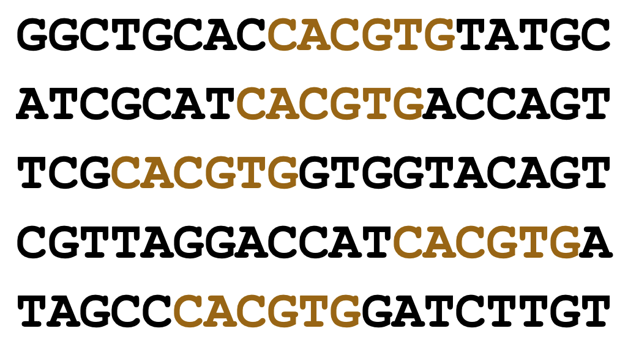

## 2.1 Data Analysis

Use `np.loadtxt('data_gibbs.npy')` to load the sequence data, $D$, of shape (number of samples x sequence length).

**Q2.1.1 Visualize the dataset as a heatmap.**

**Q2.1.2 What are the number of samples ($N$) and the length of each sequence ($L$)?**

*N = 100, L = 100*

**Q2.1.3 What is the alphabet (support) of this dataset and how many unique characters ($K$) are there?**

*Looking into data_gibbs.npy, there are K = 7 unique characters in the dataset; i.e. 0, 1, 2, 3, 4, 5, 6*

**Q2.1.4 What is a reasonable assumption regarding the distribution this data is sampled from and why?**

*A reasonable assumption is that the data was sampled from a categorical (multinomial) distribution of the 7 elements in the alphabet*

```
(100, 100)
[0. 1. 2. 3. 4. 5. 6.]
```

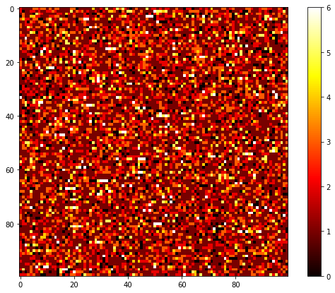

```python
#Q2.1.1
data_gibbs = np.loadtxt('data_gibbs.npy')
print(data_gibbs.shape)
print(np.unique(data_gibbs))

plt.figure(figsize=(10,7))
im = plt.imshow(data_gibbs, cmap='hot', interpolation='nearest')
plt.colorbar(im)
plt.show()
```

## 2.2 A Simple Dirichlet - Categorical Model

### 2.2.1 Generative Model

A reasonable, simple assumption is that the dataset is sampled from a Categorical Distribution. Each position ($D^n_l$) of each sequence, $D^n = \{D^n_1, \ldots, D^n_L\}$, ($n \in [N]$), is sampled i.i.d. from a Categorical Distribution $Cat(x|\theta)$. $$ D^n_l \sim Cat(x|\theta), \qquad \forall n \in [N], \quad \forall l \in [L]$$ In order to approach the problem with a Bayesian manner, we can made a further assumption and say the Categorial Distribution has a Dirichlet Distribution prior. Then, the generative model becomes $$ \theta \sim Dir(\theta|\alpha)$$ $$ D^n_l \sim Cat(x|\theta)$$

### 2.2.2. Marginal Likelihood

Assume the hyper-parameter $\alpha$ is known. Given the generative model above, we can calculate the marginal likelihood as follows

\begin{align} p(D | \alpha) &= \int_0^1 p(D, \theta | \alpha) \; d\theta \\ &= \int_0^1 p(\theta | \alpha) \; p(D | \theta, \alpha) \; d\theta \\ &= \int_0^1 p(\theta | \alpha) \; \prod_{n=1}^N p(D^n | \theta) \; d\theta \\ &= \int_0^1 Dir(\theta | \alpha) \; \prod_{n=1}^N \prod_{l=1}^L Cat(D^n_l | \theta) \; d\theta \\ &= \int_0^1 \frac{\Gamma(\sum_k^K \alpha_k)}{\prod_k^K \Gamma(\alpha_k)} \prod_{k=1}^K \theta_k^{\alpha_k-1} \; \prod_{n=1}^N \prod_{l=1}^L \prod_{k=1}^K \theta_{k}^{\mathbf{1}[k=D^n_l]} \; d\theta \\ &= \int_0^1 \frac{\Gamma(\sum_k^K \alpha_k)}{\prod_{k=1}^K \Gamma(\alpha_k)} \prod_{k=1}^K \theta_k^{\alpha_k-1+ \sum_{n=1}^N \sum_{l=1}^L \mathbf{1}[k=D^n_l]} \; d\theta \\ &= \frac{\Gamma(\sum_k^K \alpha_k)}{\prod_k^K \Gamma(\alpha_k)} \;\int_0^1 \prod_{k=1}^K \theta_k^{\alpha_k-1+ \sum_{n=1}^N \sum_{l=1}^L \mathbf{1}[k=D^n_l]} \; d\theta \\ &= \frac{\Gamma(\sum_k^K \alpha_k)}{\prod_k^K \Gamma(\alpha_k)} \;\frac{\prod_{k=1}^K \Gamma(\alpha_k + \sum_{n=1}^N \sum_{l=1}^L \mathbf{1}[k=D^n_l])}{\Gamma(|D| + \sum_k^K \alpha_k)} \\ \end{align}

In order to simplify the equation, let $D_k$ be the number of positions in the whole dataset where character $k$ is observed. The marginal likelihood becomes

\begin{align} p(D | \alpha) &= \frac{\Gamma(\sum_k^K \alpha_k)}{\Gamma(|D| + \sum_k^K \alpha_k)} \; \prod_{k=1}^K \frac{\Gamma(\alpha_k + D_k)}{\Gamma(\alpha_k)} \\ \end{align}

where $|D|$ is the total number of nucleotides in the dataset; $|D|=N \times L$.

**Q2.2.2.1 Write the marginal likelihood formula in logarithmic scale.**

*\begin{align} log\big(p(D|\alpha)\big) &= log\Big(\frac{\Gamma(\sum_k^K \alpha_k)}{\Gamma(|D| + \sum_k^K \alpha_k)}\Big) + \sum_{k=1}^Klog\Big(\frac{\Gamma(\alpha_k + D_k)}{\Gamma(\alpha_k)}\Big)\\ &= log\big(\Gamma(\sum_k^K \alpha_k)\big) - log\big(\Gamma(|D| + \sum_k^K \alpha_k)\big) + \sum_{k}^Klog\big(\Gamma(\alpha_k + D_k)\big) - \sum_{k}^Klog\big(\Gamma(\alpha_k)\big) \end{align}*

**Q2.2.2.2 Implement the function to compute the marginal log-likelihood.**

*Hint: Check `scipy.special.loggamma` function.*

**Q2.2.2.3 What are the marginal log-likelihoods ($\log p(D|\alpha)$) when $\alpha_k=1$ and $\alpha_k=0.7$ for $k \in [K]$?**

*mLL = -14,680.209 for $\alpha_k$ = 1, and mLL = -14,680.320 for $\alpha_k$ = 0.7*

```python
#Q2.2.2.2
def cat_marginal_LL(K, alpha_k, D_k):
    """alpha_k is a vector of k real numbers
       D_k is a vector of k integers"""

    sum_alpha_k = np.array(alpha_k).sum()
    D = np.array(D_k).sum()
    ll = 0
    for k in range(K):
        ll += loggamma(alpha_k[k] + D_k[k]) - loggamma(alpha_k[k])

    mLL = loggamma(sum_alpha_k) - loggamma(D + sum_alpha_k) + ll

    return(mLL)
```

```python
def cat_marginal_LL_k(k, alpha_k, D_k):
    """alpha_k is a vector of k real numbers
       D_k is a vector of k integers"""

    sum_alpha_k = np.array(alpha_k).sum()
    D = np.array(D_k).sum()
    ll = loggamma(alpha_k[k] + D_k[k]) - loggamma(alpha_k[k])

    mLLk = loggamma(sum_alpha_k) - loggamma(D + sum_alpha_k) + ll

    return(mLLk)
```

```python
#Q.2.2.2.3
K = np.unique(data_gibbs).size
D_k = [np.count_nonzero(data_gibbs==k) for k in range(K)]
print(D_k)

alpha_k1 = [1 for k in range(K)]
mLL1 = cat_marginal_LL(K, alpha_k1, D_k)
print(mLL1)

alpha_k2 = [.7 for k in range(K)]
mLL2 = cat_marginal_LL(K, alpha_k2, D_k)
print(mLL2)
```

```
[884, 4794, 2071, 1418, 292, 358, 183]
-14680.208776634681
-14680.319916425375
```

## 2.3 A More Advanced Dirichlet - Categorical Model

### 2.3.1 Generative Model

Up until now, we assumed all the positions of the dataset is sampled i.i.d. from a single Categorical Distribution, $Cat(x|\theta)$ with a Dirichlet prior $Dir(\theta|\alpha)$.

Now, we assume each sequence $D^n$, has a *motif* of length $W$ hidden in it. These motifs are sampled from a different distribution from the rest of the sequences. The motifs of each sequence look similar to each other, and different then the rest of the dataset (which we will call *background*).

In the below heatmaps, we visualized the complete dataset (top) and the magic words in it (bottom).

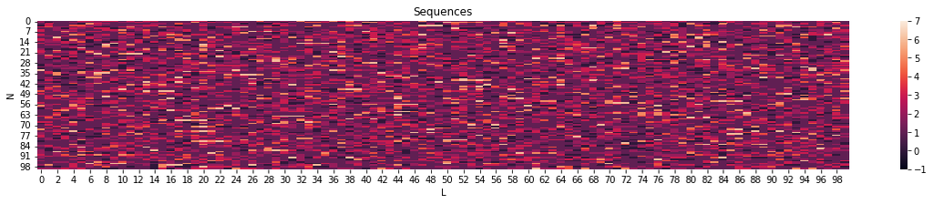

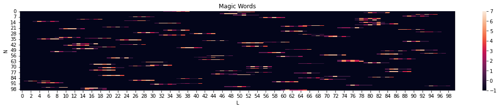

**Q2.3.1.1 What can you say about the magic words, is there a pattern?**

For easiness, we can represent the dataset in two disjoint sets; $D = \{D_B \cup D_M\}$, where $D_B$ is the background data and $D_M$ is the motif data.

If we consider the example "perfect" figure at the beginning of this exercise, we have:

$D$ = \begin{bmatrix} GGCTGCACCACGTGTATGC \\ ATCGCATCACGTGACCAGT \\ TCGCACGTGGTGGTACAGT \\ CGTTAGGACCATCACGTGA \\ TAGCCCACGTGGATCTTGT \end{bmatrix}

$D_B$ = \begin{bmatrix} GGCTGCACTATGC \\ ATCGCATACCAGT \\ TCGGTGGTACAGT \\ CGTTAGGACCATA \\ TAGCCGATCTTGT \end{bmatrix}

$D_M$ = \begin{bmatrix} CACGTG \\ CACGTG \\ CACGTG \\ CACGTG \\ CACGTG \end{bmatrix}

In this more advanced model, we further assume each position of the motif ($w \in [W]$) is sampled from a different Categorical Distribution. These Categorical Distributions have a Dirichlet prior and they share the same hyperparameter $\alpha_m$.

$$ \theta_{mw} \sim Dir(\theta_{mw}|\alpha_{m})$$$$ D_{Mw}^n \sim Cat(x|\theta_{mw})$$

All the non-motif parts of the datasets (*background*) is sampled from a single Categorical Distribution with Dirichlet prior.
$$ \theta_{b} \sim Dir(\theta_{b}|\alpha_{b})$$ $$ D_{Bl}^n \sim Cat(x|\theta_{b})$$

Finally, the starting positions of the motifs of each sequence, $R^n$, is sampled from a Uniform Distribution $$ R^n \sim U[1, L-W+1]$$

### 2.3.2 Marginal Likelihood

Since the model has two parts; background and motif, we should formulate the marginal likelihood accordingly. Given the Dirichlet hyperparameters ($\alpha_{b}$ and $\alpha_{m}$) and the starting positions of the motifs ($R$), the marginal likelihood is

\begin{align} p(D | R, \alpha_{b}, \alpha_{m}) &= \prod_{n=1}^N p(D^n | R^n, \alpha_{b}, \alpha_{m}) \\ &= \prod_{n=1}^N p(D_B^n | \alpha_{b}) \; p(D_M^n | \alpha_{m}) \\ &= \prod_{n=1}^N p(D_B^n | \alpha_{b}) \; \prod_{w=1}^W p(D_{Mw}^n | \alpha_{m}) \\ \end{align}

where $D_B^n$ is $n$'th sequence's background values and $D_M^n$ is $n$'th sequence's motif defined by the motif start position ($R^n$). $D_{Mw}^n$ is the motif's $w$'th position.

**Q2.3.2.1 What is the marginal log-likelihood formula of the background data, $\log p(D_B | \alpha_{b})$?**

*As have been corrected in Canvas, the marginal likelihood needs to be computed for each sequence and thus has the form of:*

\begin{align} p(D^n | R^n, \alpha_{b}, \alpha_{m}) &= p(D_B^n | \alpha_{b}) \; p(D_M^n | \alpha_{m}) \\ &= p(D_B^n | \alpha_{b}) \; \prod_{w=1}^W p(D_{Mw}^n | \alpha_{m}) \\ \end{align}

*Then, we can follow the same derivation as for the marginal log-likelihood of the general nucleotide position from 2.2.2; the marginal log-likelihood for the background data of **sequence n** is hence:*

\begin{align} \log p(D_B^n | \alpha_{b}) &= \log\Big(\frac{\Gamma(\sum_k^K \alpha_{b,k})}{\Gamma(|D_B^n| + \sum_k^K \alpha_{b,k})}\Big) + \sum_{k=1}^K \log\Big(\frac{\Gamma(\alpha_{b,k} + D_{B,k}^n)}{\Gamma(\alpha_{b,k})}\Big)\\ &= \log\big(\Gamma(\sum_k^K \alpha_{b,k})\big) - \log\big(\Gamma(|D_B^n| + \sum_k^K \alpha_{b,k})\big) + \sum_{k}^K \log\big(\Gamma(\alpha_{b,k} + D_{B,k}^n)\big) - \sum_{k}^K \log\big(\Gamma(\alpha_{b,k})\big) \end{align}

*where $\alpha_{b,k}$ is the pseudo-count (Dirichlet parameter) for the k-th alphabetic symbol in the background data, $|D_B^n| = |D^n| - |D_M^n|$ is the (observable) number of nucleotides not in any of the motifs in sequence n, and $D_{B,k}^n$ is the (observable) number of k-th symbol contained in the background data of sequence n*

**Q2.3.2.2 What is the marginal log-likelihood formula of the the motif's $w$'th position, $\log p(D_{Mw} | \alpha_{m})$?**

*The marginal likelihood for the w-th position in motif data of **sequence n** is:*

\begin{align} p(D_{Mw}^n | \alpha_m) &= \frac{\Gamma(\sum_k^K \alpha_{m,k})}{\Gamma(|D_{Mw}^n| + \sum_k^K \alpha_{m,k})} \; \prod_{k=1}^K \frac{\Gamma(\alpha_{m,k} + D_{Mw,k}^n)}{\Gamma(\alpha_{m,k})} \\ \end{align}

*where $|D_{Mw}^n|$ is the total number of nucleotides on the w-th position in the motif data, and $|D_M^n|=\sum_{w=1}^W|D_{Mw}^n|$*

*Thus, the marginal log-likelihood of the w-th position in the motif data is:*

\begin{align} \log p(D_{Mw}^n | \alpha_m) &= \log\Big(\frac{\Gamma(\sum_k^K \alpha_{m,k})}{\Gamma(|D_{Mw}^n| + \sum_k^K \alpha_{m,k})}\Big) + \sum_{k=1}^K \log\Big(\frac{\Gamma(\alpha_{m,k} + D_{Mw,k}^n)}{\Gamma(\alpha_{m,k})}\Big)\\ &= \log\big(\Gamma(\sum_k^K \alpha_{m,k})\big) - \log\big(\Gamma(|D_{Mw}^n| + \sum_k^K \alpha_{m,k})\big) + \sum_{k}^K \log\big(\Gamma(\alpha_{m,k} + D_{Mw,k}^n)\big) - \sum_{k}^K \log\big(\Gamma(\alpha_{m,k})\big) \end{align}

*again, where $\alpha_{m,k}$ is the pseudo-count (Dirichlet parameter) for the k-th symbol on the w-th position in the motif data of sequence n, $D_{Mw,k}^n$ is the (observable) number of k-th symbol contained on the w-th position in the motif data of sequence n*

## 2.4 Gibbs Sampler

In reality, we don't know the start positions of the motifs, we want to identify them. We are interested in the posterior probability of the starting positions, $p(R^1,\ldots,R^N | D^1, \ldots, D^N, \alpha_{b}, \alpha_{m})$.

Recall from the lectures that we need the full-conditionals to sample each latent variable.

We can express the Gibbs update as

\begin{align} R^{n} &\sim p(R^n | R^{\neg n}, D, \alpha_{b}, \alpha_{m}) \\ \end{align}

where $R^{\neg n} = \{ R^1,\ldots, R^{n-1}, R^{n+1},\ldots, R^N \}$.

\begin{align} p(R^n | R^{\neg n}, D, \alpha_{b}, \alpha_{m}) &= \frac{p(R, D | \alpha_{b}, \alpha_{m})}{p(R^{\neg n}, D | \alpha_{b}, \alpha_{m}) } \\ &= \frac{p(D | R, \alpha_{b}, \alpha_{m}) p(R | \alpha_{b}, \alpha_{m})}{p(R^{\neg n}, D | \alpha_{b}, \alpha_{m}) } \\ &\propto p(D | R, \alpha_{b}, \alpha_{m}) \end{align}

We are able to get the last line above simply because i) the denominator ($p(R^{\neg n}, D | \alpha_{b}, \alpha_{m})$) does not depend on $R^n$ and ii) we assumed starting positions ($p(R | \alpha_{b}, \alpha_{m})$) are sampled i.i.d. from Uniform Distribution.

**Q2.4.1 Implement the Gibbs sampler and run on the given data.**

*Use `np.loadtxt('data_gibbs.npy')` for the sequence data. Set $\alpha_{bk} = 1$ and $\alpha_{mk}=0.4$ for $k \in[K]$. The motif length is $W=6$*.

*Hint: Make sure to do the calculations in the logarithmic scale for numeric stability.*

**Q2.4.2 What are the settings you used (number of iterations, burnin etc.)?**

*Nr. of chains: 4; Nr. of iterations per chain: 12,500; No burning-in (0%) and no thinning -because apparently my chains are still too short :P*

**Q2.4.3 Which convergence diagnostics did you use? Provide some of them here and discuss your observations.**

*Autocorrelation function (ACF) plots; see below.*

*Apparently, due to the nature the data (categorical), no substantial autocorrelation across time-lags was observed either within an iteration or for a particular sequence across all iterations and chains (see below). Thus, thinning may not even be needed here.*

**Q2.4.4 What do you think the starting positions of the motifs are? Report a list of $N$ positions.**

*Positions = [36, 50, 47, 61, 89, 51, 87, 23, 56, 77, 13, 77, 26, 45, 79, 31, 89, 77, 64, 62, 77, 74, 10, 88, 34, 60, 79, 76, 40, 63, 34, 68, 28, 8, 4, 5, 24, 43, 88, 58, 52, 13, 25, 10, 53, 67, 36, 50, 35, 89, 84, 92, 32, 91, 81, 69, 44, 62, 58, 21, 12, 40, 69, 74, 26, 81, 35, 15, 29, 27, 54, 17, 50, 85, 57, 45, 85, 61, 66, 78, 50, 17, 39, 81, 18, 36, 69, 25, 2, 58, 79, 36, 37, 75, 93, 6, 55, 14, 30, 40]*

**Q2.4.5 Use the provided `calculate_accuracy` function below and report the accuracy of your starting positions.**

*22.0%*

*Note: As I said above, my chains are still too short, but I'm lacking a serious computational power atm, so I have no choice but just go and report this rather minimal number of iterations. I observed that the more iterations I added (previously, from 2000 x3 to 5000 x3, and now to 12,500 x4) the better the accuracy became.*

*In the spirit of being not too stringet in assessing the results match/mismatch, as with the exact accuracy metric you provided here, I also calculated the mean absolute error (MAE) which takes into account how far in terms of position my result deviates from the true positions given. And the number (of the MAE) is 10.59; i.e. on average, my guesses miss the mark by 11 positions per sequence.*

**Q2.4.6 Plot one histogram for each motif position, using the Gibbs samples you obtained.**

*Please see below*

**Q2.4.7 Which Gibbs sampling did we implement in this exercise (standard, collapsed or blocked)? Motivate your answer.**

*Technically, it is a collapsed Gibbs sampling, as we marginalize out the theta parameters (hence, they are not sampled) to obtain the eventual density factorization*

```python
def run_a_Gibbs_chain(T, N, L, W, alpha_mk, alpha_bk):
    """T = number of sampling iterations
       N = number of sequences
       L = sequence length (assumed to be all the same)
       W = motif length (assumed to be all the same)
       alpha_mk = vector of pseudo-count for the k-th symbol in the motif data
       alpha_bk = vector of pseudo-count for the k-th symbol in the background data"""

    K = len(alpha_mk)

    chain_of_positions = {}
    motif_mask = np.zeros((N,L), dtype=bool)  #starting position of motif is the 1st nucleotide in all sequences
    motif_mask[:,:W] = True

    for t in range(T):
        positions = []    #empty the position vectors for the next iteration

        for n in range(N):
            rest_data = np.delete(data_gibbs, n, axis=0)
            matrix = {}
            for w in range(W):
                motif_data = rest_data[np.delete(motif_mask, n, axis=0)].reshape((N-1),W)
                matrix[w] = [np.count_nonzero(motif_data[:,w]==k) for k in range(K)]

            bg_freq = [np.count_nonzero(rest_data[np.delete(~motif_mask, n, axis=0)]==k) for k in range(K)]
            bgLL = [cat_marginal_LL_k(k, alpha_bk, bg_freq) for k in range(K)]

            Scores_SnLL = []
            CumScores_SnLL = []
            CumScores_pwSnLL = 0
            for l in range((L-W+1)):
                Score_pwSnLL = 0
                for w in range(W):
                    Score_pwSnLL += cat_marginal_LL_k(int(data_gibbs[n,l:l+W][w]), alpha_mk, matrix[w]) - bgLL[int(data_gibbs[n,l:l+W][w])]

                if l == 0:
                    CumScores_pwSnLL = Score_pwSnLL
                else:
                    CumScores_pwSnLL += Score_pwSnLL

                Scores_SnLL.append(Score_pwSnLL)
                CumScores_SnLL.append(CumScores_pwSnLL)

            toss = np.random.uniform(CumScores_SnLL[-1])
            pos_n = next(x[0] for x in enumerate(CumScores_SnLL) if x[1] > toss)
            positions.append(pos_n)
            motif_mask[n, :] = np.zeros(L, dtype=bool)
            motif_mask[n, pos_n:pos_n+W] = True

        chain_of_positions[t] = positions

    return(chain_of_positions)
```

```python
t0 = time.time()

alpha_mk = [.4]*7
alpha_bk = [1]*7
nr_chains = 4
iters = 12500

chains = {}
for i in range(nr_chains):
    chains[i] = run_a_Gibbs_chain(iters, 100, 100, 6, alpha_mk, alpha_bk)

t1 = time.time()
total_time = t1 - t0
print('total time is', total_time//3600, 'hour', (total_time%3600)//60, 'minute', (total_time%3600)%60, 'seconds')
```

```
total time is 16.0 hour 34.0 minute 24.03308367729187 seconds
```

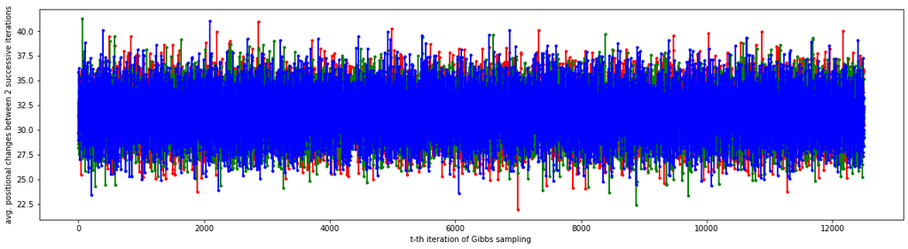

```python
chain_diffs = {}

for c in range(len(chains)):
    iters = len(chains[c])
    iter_diffs = []
    for i in range(iters-1):
        diff = []
        for i,j in zip(chains[c][i], chains[c][i+1]):
            diff.append(abs(j - i))

        iter_diffs.append(sum(diff)/100)

    chain_diffs[c] = iter_diffs

#print(chain_diffs[0])
plt.rc("figure", figsize=(20,5))
plt.plot(range(1,iters), chain_diffs[0], 'r.-')
plt.plot(range(1,iters), chain_diffs[1], 'g.-')
plt.plot(range(1,iters), chain_diffs[2], 'b.-')
plt.xlabel('t-th iteration of Gibbs sampling')
plt.ylabel('avg. positional changes between 2 successive iterations')
```

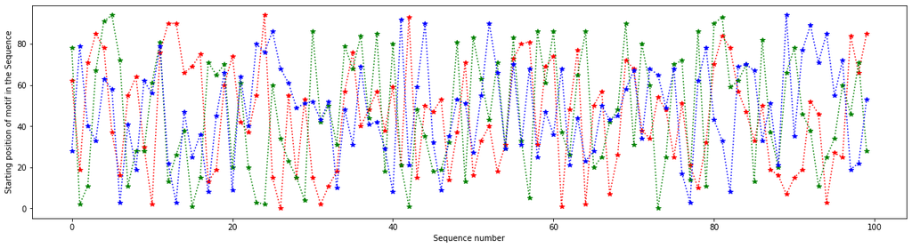

```python
which_iter = iters-1   #t-th sampling iteration

plt.rc("figure", figsize=(20,5))
plt.plot(np.array(chains[0][which_iter]), 'r*:')
plt.plot(np.array(chains[1][which_iter]), 'g*:')
plt.plot(np.array(chains[2][which_iter]), 'b*:')
plt.xlabel('Sequence number')
plt.ylabel('Starting position of motif in the Sequence')
```

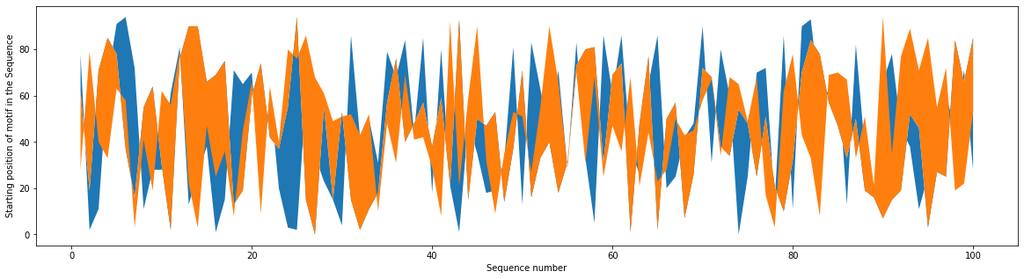

```python
plt.rc("figure", figsize=(20,5))
plt.fill_between(range(1,101), np.array(chains[0][which_iter]), np.array(chains[1][which_iter]))
plt.fill_between(range(1,101), np.array(chains[0][which_iter]), np.array(chains[2][which_iter]))
plt.xlabel('Sequence number')
plt.ylabel('Starting position of motif in the Sequence')
```

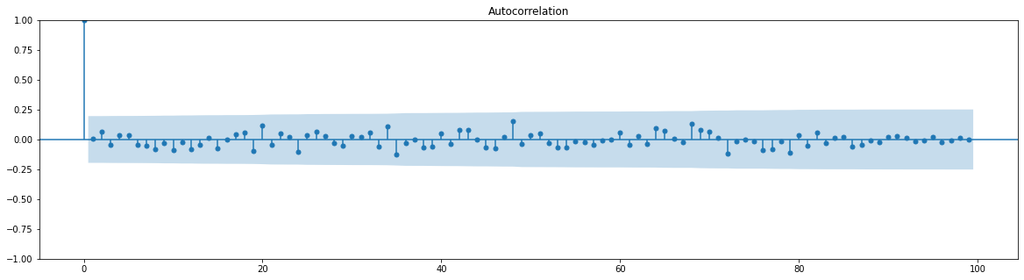

```python
plt.rc("figure", figsize=(20,5))
plt.figure(figsize=(20,5))
plot_acf(np.array(chains[2][which_iter]), lags=99)
plt.show()
```

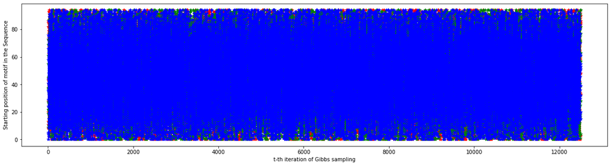

```python
chains_n_seq = {}
which_sequence = 99   #one of the {0 - 99} sequences

for c in range(len(chains)):
    n_seq = [chains[c][i][which_sequence] for i in chains[c].keys()]
    chains_n_seq[c] = n_seq

plt.rc("figure", figsize=(20,5))
plt.figure(figsize=(20,5))
plt.plot(range(1,iters+1), chains_n_seq[0], 'r*:')
plt.plot(range(1,iters+1), chains_n_seq[1], 'g*:')
plt.plot(range(1,iters+1), chains_n_seq[2], 'b*:')
plt.xlabel('t-th iteration of Gibbs sampling')
plt.ylabel('Starting position of motif in the Sequence')
```

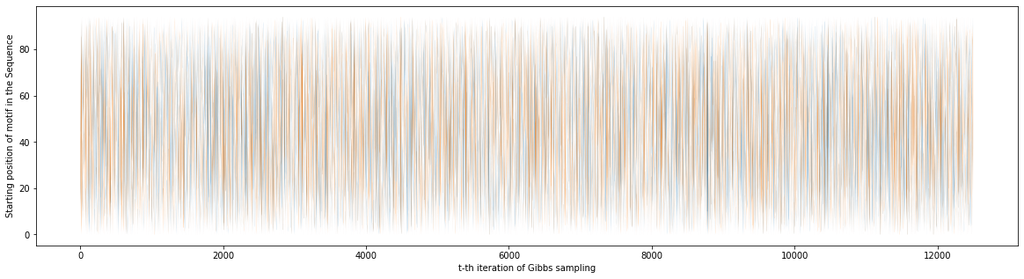

```python
plt.rc("figure", figsize=(20,5))
plt.fill_between(range(1,iters+1), np.array(chains_n_seq[0]), np.array(chains_n_seq[1]))
plt.fill_between(range(1,iters+1), np.array(chains_n_seq[0]), np.array(chains_n_seq[2]))
plt.xlabel('t-th iteration of Gibbs sampling')
plt.ylabel('Starting position of motif in the Sequence')
```

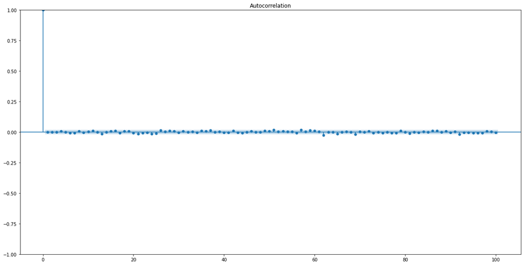

```python
plt.rc("figure", figsize=(20,10))
plt.figure(figsize=(20,10))
plot_acf(chains_n_seq[0], lags=100)
plt.show()
```

```
[28 79 40 33 63 58  3 41 19 62 56 79 22  3 47 25 36  8 45 66  9 64 40 80
 76 86 68 61 49 51 52 43 52 10 48 31 69 41 42 29  8 92 21 59 90 32  9 35
 53 51 27 55 90 66 29 70 31 68 25 47 36 68 21 44 23 28 50 43 45 58 67 34
 68 65 49 68 17  3 62 78 43 33  8 69 70 67 33 51 21 94 35 77 89 71 85 55
 72 19 22 53]
```

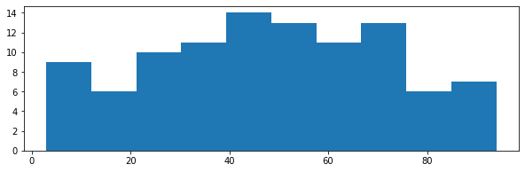

```python
plt.rc("figure", figsize=(10,3))
print(np.array(chains[2][iters-1]))
plt.hist(np.array(chains[2][iters-1]))
```

```
[46 19 70 10 35 48 42 80 81 93 47 42 14 35 47 39 23 36  3 56 64 36 64 61
 44 48 72 66 87 38 15 19 57  3 64 11 73 48 91 33 70 46  3 60 72 39 44 33
 40 30  2 12 88 20 79 57 47 18 69 18  4 90 71 60 68 29  1 26 80 82  0 54
 78  2 43 54 11 64 34  6 22 41 86 38 49 37 34  5 30  0 36 69 69 38 62 50
 57 14 89 48]
```

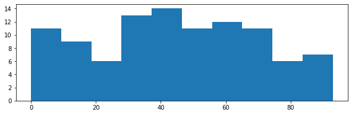

```python
plt.rc("figure", figsize=(10,3))
print(np.array(chains[0][iters-2]))
plt.hist(np.array(chains[0][iters-2]))
```

```python
# consolidating all sampling chains
all_sequence_chains = {}

for n in range(100):
    chains_n_seq = {}

    for c in range(len(chains)):
        n_seq = [chains[c][i][n] for i in chains[c].keys()]
        chains_n_seq[c] = n_seq

    all_sequence_chains[n] = chains_n_seq

burn_in = .0
thinning = 1
begin_include_iter = int(burn_in * iters)
taken_iterations = np.linspace(begin_include_iter, iters, int((iters-begin_include_iter)*thinning)).astype(int)-1
taken_sample_mask = np.zeros(iters, dtype=bool)
taken_sample_mask[taken_iterations] = True

all_sequence_pos = {}
for n in range(100):

    all_sampled_positions_of_n_seq = []
    for c in range(nr_chains):
        #for t in range(begin_include_iter, iters):
        n_seq_c_chain = np.array(all_sequence_chains[n][c])[taken_sample_mask]
        all_sampled_positions_of_n_seq.extend(list(n_seq_c_chain))

    all_sequence_pos[n] = all_sampled_positions_of_n_seq

#all_position_freq = [np.count_nonzero(np.array(all_sampled_positions)==l) for l in range(100)]
#all_position_rel_freq = np.array(all_position_freq) * 4784/sum(all_position_freq)
#print(all_position_rel_freq)
#plt.bar(range(100), all_position_rel_freq)
```

```
[474 509 555 566 620 607 626 545 585 555 566 505 494 482 468 497 535 540
 521 509 494 451 443 454 463 538 493 558 485 478 519 506 604 586 600 600
 628 577 600 505 497 474 481 486 472 519 509 550 489 496 529 555 499 503
 522 475 464 531 570 565 546 540 572 490 501 464 523 522 482 489 505 545
 474 511 557 533 489 485 505 486 502 460 527 565 539 524 579 571 573 626
 559 559 542 581]
36
```

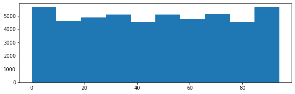

```python
which_sequence_fin = 0   #one of the {0 - 99} sequences
plt.rc("figure", figsize=(10,3))
plt.hist(all_sequence_pos[which_sequence_fin])

counts = np.array([np.count_nonzero(np.array(all_sequence_pos[which_sequence_fin])==l) for l in range(94)])
print(counts)
print(np.where(counts == counts.max())[0][0])
```

```
[36 50 47 61 89 51 87 23 56 77 13 77 26 45 79 31 89 77 64 62 77 74 10 88
 34 60 79 76 40 63 34 68 28  8  4  5 24 43 88 58 52 13 25 10 53 67 36 50
 35 89 84 92 32 91 81 69 44 62 58 21 12 40 69 74 26 81 35 15 29 27 54 17
 50 85 57 45 85 61 66 78 50 17 39 81 18 36 69 25  2 58 79 36 37 75 93  6
 55 14 30 40]
```

```
<BarContainer object of 100 artists>
```

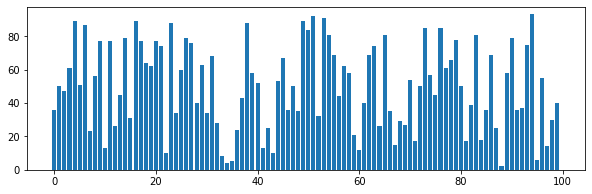

```python
all_seq_counts = {}
all_seq_start_pos = []
for n in range(100):
    all_seq_counts[n] = np.array([np.count_nonzero(np.array(all_sequence_pos[n])==l) for l in range(94)])
    all_seq_start_pos.append(np.where(all_seq_counts[n] == all_seq_counts[n].max())[0][0])

R_estimated = np.array(all_seq_start_pos)
print(R_estimated)
plt.rc("figure", figsize=(10,3))
plt.bar(range(100), R_estimated)
```

```python
def calculate_accuracy(R_estimated):
  """ R_estimated and true_R are numpy arrays of shape (N,) """
  true_R = np.loadtxt("true_R.npy").astype(int)
  accuracy = 100 * np.sum(np.equal(true_R, R_estimated.astype(int))) / len(true_R)
  return accuracy
```

```python
calculate_accuracy(R_estimated)
```

```
22.0
```

```
[33 48 79 46 90 49 88 25 55 77 13 77 24  3 78 31 81 77 64 60 19 73  9 87
 33 60 91 26 39 64 32 67 70  8 15  4 22 42 88 56 50 12 23 10 51 16 36 12
 61 90 83  7 55 92 82 69 43 59 40 20 85 41 73 73 28 79 64 16 29 25 52 18
 52 84 16 45 84 52 63 44 48 18 70 80 64 36 69 25  1 58  4 36 30 75 93 47
  5 14 14 60]
```

```
<BarContainer object of 100 artists>
```

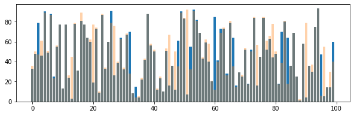

```python
# the most likely motif's starting position in each sequence
true_R = np.loadtxt("true_R.npy").astype(int)
print(true_R)
plt.rc("figure", figsize=(10,3))
plt.bar(range(100), true_R)
plt.bar(range(100), R_estimated, alpha=.35)
```

```python
abs_err = np.array([abs(true_R[n] - R_estimated[n]) for n in range(len(true_R))])
mae = abs_err.mean()
print(mae)
```

```
10.59
```

# *3. Metropolis-Hastings*

Remember the non-standard multimodal distribution we analysed in Assignment 1? We will work with the same data in this task.

Recall that in Assignment 1, we were not equipped to accurately approximate the distribution. There we tried to match existing, standard distributions by tuning their parameters, which is a common approach in both research and industry (e.g., Gaussianity is often assumed in data analysis).

Here, you will learn to approximate the distribution of the *parameters*, $\theta$, that generated the data. Note that this is similar to what you did in Assignment 1 when you tuned the parameters of a Gamma, Normal, or whichever distribution you chose, in order to fit the data. Now you will instead get a distribution over the parameters, $p(\theta|\mathcal{D})$.

Additionally, we will now assume a more complicated likelihood model, $p(\mathcal{D}|\theta)$, which will increase our accuracy. Being able to approximate $p(\theta|\mathcal{D})$ is a great tool in data analysis, as it allows you to reason about uncertainty, do anomaly detection, requires you to understand your data, sample new data, and much more.

We have $$p(\theta|\mathcal{D}) \propto p(\mathcal{D}|\theta) p(\theta),$$ where we assume that $p(\mathcal{D}|\theta)$ is a mixture of log-normal distributions, and that $p(\theta)$ is a uniform prior over the whole real line. Note, that one can easily go with other choices of priors and likelihoods! Our choices here are motivated by $p(\mathcal{D}|\theta)$ being non-zero only on the positive real line, and by that we may omit computing $p(\theta)$ in the Metropolis-Hastings algorithm (since it considers all proposed $\theta$'s as equiprobable).

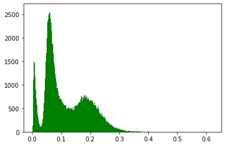

```python
D = np.load('ass1_dist.npy')
plt.hist(D, bins=1000, facecolor='g')
plt.show()
```

## 3.1 Mixture Model

By observing the histogram, we can make some *assumptions* about the underlying distribution:

- There are at least three modes
- Continuous random variable
- The support of the values is $> 0$.

For the remaining of this task, we will assume the underlying distribution is a **mixture of** [**Log-Normal Distributions**](https://en.wikipedia.org/wiki/Log-normal_distribution).

### 3.1.1 Likelihood

**Q3.1.1.1 Assuming $N$ data points are i.i.d. sampled from a Log-Normal Mixture Model with $K$ mixtures, derive the loglikelihood formula.**

*A mixture model of K log-normal components has the following general form of likelihood:*

\begin{equation} p(\mathcal{D}|\theta_{1:K}) = \prod_{i=1}^N \sum_{k=1}^K \phi_k LN(x_i; \mu_k, \sigma_k^2) \end{equation}

*where $LN(x; \mu, \sigma)$ stands for log-normal distribution function, $\theta = (\phi, \mu, \sigma)$, and $\sum_k^K\phi_k = 1$*

*Then,*

\begin{align} \log p(\mathcal{D} | \theta_{1:K})= \sum_{i=1}^N \log\Big(\sum_{k=1}^K\phi_k \frac{1}{x_i\sqrt{2\pi\sigma_k^2}}\exp^{-\frac{(log x_i - \mu_k)^2}{2\sigma_k^2}} \Big) \end{align}

**Q3.1.1.2 Implement a function that computes the loglikelihood of the dataset, $\mathcal{D}$, given the mixture model parameters, $\theta_{1:K}$ efficiently.**

*Hint: Make sure to do the calculations in the logarithmic scale for numeric stability.*

*We recommend you to implement a very efficient function, which uses the capabilities of `numpy`, `scipy` and/or other scientific libraries as much as possible.*

*Beware of the differences between `numpy` and `scipy` regarding the log-Normal distribution.*

```python
def compute_LNmixture_LL(data, phi_k, mu_k, sigma_k):
    """data is an array of N real numbers (literally *the* data)
       phi_k is a vector of K mixture weights
       mu_k is a vector of K log-normal means
       sigma_k is a vector of K log-normal standard deviations"""
    K = len(phi_k)

    LL = 0
    for i in data:
        kernel_vec = lognorm.pdf(i, s=sigma_k, loc=mu_k)+1e-4
        LL += np.log(np.dot(phi_k, kernel_vec))

    return(LL)
```

### 3.1.2 Visualization

In the upcoming parts of this exercise, we would like to plot the inferred mixture model and see how well it describes the observed data.

**Q3.1.2.1 Write a function that visualizes both the observed data and the mixture model in the same plot, just like you did in Assignment 1. Make sure both distributions are visible.**

*In Assignment 1, you sampled some data points from $q(x)$, which was a standard distribution that is available in libraries. Here, you should sample some data points from a Log-Normal mixture model.*

**Q3.1.2.2 Show an example plot with $K>2$, with your choice of mixture model parameters.**

*An example plot with the following params: $\theta = (\phi = [.05, .51, .44], \mu = [-4.5, -2.7, -1.65], \sigma = [.27, .28, .26])$ is shown below*

```python
#Q3.1.2.1 A function to sample N data points form a mixture of K log-normal components
def LNmixture_sampler(N, phi_k, mu_k, sigma_k):
    """N is a number of data points to be sampled
       phi_k is a vector of K mixture weights
       mu_k is a vector of K log-normal means
       sigma_k is a vector of K log-normal standard deviations"""
    K = len(phi_k)

    samples = []
    for i in range(N):
        k = np.random.choice(np.arange(K), p=phi_k)
        x_i = np.random.lognormal(mean=mu_k[k], sigma=sigma_k[k])
        samples.append(x_i)

    return(samples)
```

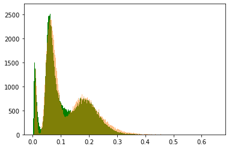

```python
#Q3.1.2.2 An example plot with K = 3 components, the above-mentioned params, and N = 330,000 samples
my_sample = LNmixture_sampler(D.size, [.05, .51, .44], [-4.5, -2.7, -1.65], [.27, .28, .26])

plt.hist(D, bins=1000, facecolor='g')
plt.hist(my_sample, bins=1000, alpha=.5)
plt.show()
```

## 3.2 Metropolis-Hastings

In this section, we will go over some key aspects of MH algorithm one by one, and combine them in the end.

### 3.2.1 Acceptance Ratio

Recall from the lectures, the acceptance ratio of MH is

\begin{align} A(z', z) &= min \Big(1, \; \frac{f(z')}{f(z)} \; \frac{q(z|z')}{q(z'|z)} \Big) \\ \end{align}

where $z$ is the current model parameters, $z'$ is the proposed model parameters, $f(.)$ is the function proportional to the target density and $q(.|.)$ is the transition probability from one state to the other.

In order to avoid numeric unstabilities, one can work in logarithmic scale (since logarithm is a monotonically increasing function).

**Q3.2.1 Re-write the acceptance ratio in logarithmic scale and describe how to decide accepting or rejecting proposed model parameters, given its acceptance ratio in logartihmic scale.**

*The acceptance ratio in logarithmic scale would be:*

\begin{align} \log A(z', z) &= min\Big(\log 1, \; \log\Big(\frac{f(z')}{f(z)}\frac{q(z|z')}{q(z'|z)}\Big)\\ &= min\big(0, \; [\log f(z') - \log f(z)] + [\log q(z|z') - \log q(z'|z)] \big) \end{align}

*where the minimum rule for acceptance remains the same because applying logarithm will not change the ordering of values (i.e. it is a monotonically increasing function). If we use a symmetric proposal distribution, e.g. a Gaussian, then the rule reduces to:*

\begin{equation} \log A(z', z) = min\big(0, \; [\log f(z') - \log f(z)] \big) \end{equation}

### 3.2.2 Proposing States

It is important to decide how to propose new states $z'$ given the current state $z$.

**Q3.2.2.1 For each latent variable in the Log-Normal Mixture Model; state the name and constraints (if any) of the latent variable. Describe a way to propose new state $z'$ given the current state of your latent variable. Motivate the contraints and your choice of proposals.**

*The **cluster variable** (to choose which among the K mixtures) is a latent variable, it takes a value of {1,2,..,K}, and it has a distribution of $\pi(z_i = k|w) = w_k$, where k = {1,..., K} and $\sum_k^K w_k = 1$ which then can be a Dirichlet distribution*

**Q3.2.2.2 Implement your new state proposal functions for all parameters except the cluster probabilities.**

```python
def Gaussian_state_proposal(k_current_states, proposal_sd_multiplier, limits):
    """k_current_states is a vector of K values of the parameter from the previous iteration
       proposal_sd_multiplier is a real number of I matrix multiplier; i.e. sd = 1*multiplier
       limits is a 2D-vector of upper and lower limits for the value of the parameter"""

    K = k_current_states.size
    generated = np.random.multivariate_normal(k_current_states, np.identity(K)*proposal_sd_multiplier)
    if limits != [None, None]:
        proposals = list(np.clip(generated, limits[0], limits[1]))
    else:
        proposals = generated

    return(proposals)
```

```python
def Dirichlet_state_proposal(alphas):
    """alphas is a vector of K Dirichlet hyperparams; default is a non-informative prior"""

    proposals = np.random.dirichlet(alphas)

    return(proposals)
```

### 3.2.3 Final Algorithm

So far, we worked with most of the necessary components of the MH algorithm. Now we will combine all the components.

**Q3.2.3.1 Given observed data ($\mathcal{D}$) and the number of mixtures ($K$), implement a function that performs Metropolis-Hastings algorithm.**

*For simplicty, you can assume uniform cluster probability and don't update it during MH. But if you are up for a challenge, you can disregard the previous sentence and infer the cluster probabilities during MH as well.*

**Q3.2.3.2 Run your MH algorithm on given dataset and use a model with $K=3$ mixtures.**

- State the parameters you used (e.g number of iterations, the seed value for reproproducibility, the temperature (if used), number of burnin samples (or fraction), how many chains did you run...) during your run.
- Plot the mixture model together with the observed data at initialization, final iteration and a number of times in between.
- Plot how the loglikelihood of the data changes across iterations.
- What is the acceptance rate?

*Try to implement MH code as efficient as possible.*

*Even after an efficient implementation, if you have problems working with the complete dataset, you may use a subset of it. In that case i) make sure to shuffle the given dataset and ii) randomly pick at least $10,000$ data points from it iii) visualize both complete data and the selected subset of the data and iv) make sure you observe a similar distribution as the complete dataset.*

**Q3.2.3.3 Which convergence diagnostics did you use? Provide some of them here and discuss your observations.**

*{ First of all, again, very sorry for the very short chain, but this is all that was possible with the sordid machine I had with me right now (due to some problem, I cannot access my desktop PC at the office -which definitely packs so much more power than this personal laptop I am using- at the office for almost a week already). }*

*Autocorrelation function (ACF) plots; see below.*

*In general sampled values for all parameters showed much stronger (compared those observed with Gibbs sampling) autocorrelation patterns over very long time lags. The strength of these correlations fell only slowly even over hundreds of time-lags away, with the exception of the phi paramters which were sampled from a Dir(1,1,1).*

**Q3.2.3.4 What are your observations regarding the performance of the MH algorithm?**

*Feel free to run MH for different number of mixtures ($K$), step sizes etc.*

```python
def run_a_MH_chain(data, T, start_theta):
    current_theta = np.array(start_theta)
    n_params = current_theta.size

    sampled_theta = {}
    phi = []; mu = []; sigma = []
    flag = []; accepts = []
    for t in range(T):

        proposed_phi = list(Dirichlet_state_proposal([1,1,1]))
        proposed_mu = list(Gaussian_state_proposal(current_theta[3:6], 5e-2, [None, None]))
        proposed_sigma = list(Gaussian_state_proposal(current_theta[6:9], 1e-2, [1e-2, None]))

        log_accept_ratio = compute_LNmixture_LL(data, phi_k=proposed_phi, mu_k=proposed_mu, sigma_k=proposed_sigma) - compute_LNmixture_LL(data, phi_k=current_theta[:3], mu_k=current_theta[3:6], sigma_k=current_theta[6:9])
        if log_accept_ratio >= 0:
            phi.extend(proposed_phi)
            mu.extend(proposed_mu)
            sigma.extend(proposed_sigma)
            current_theta = np.array(proposed_phi + proposed_mu + proposed_sigma)
            flag.append(1)
        else:
            u = np.random.uniform(0, 1)
            if u < np.exp(log_accept_ratio/data.size):
                phi.extend(proposed_phi)
                mu.extend(proposed_mu)
                sigma.extend(proposed_sigma)
                current_theta = np.array(proposed_phi + proposed_mu + proposed_sigma)
                flag.append(1)
            else:
                phi.extend(current_theta[:3])
                mu.extend(current_theta[3:6])
                sigma.extend(current_theta[6:9])
                flag.append(0)

        sampled_theta["phi"] = phi
        sampled_theta["mu"] = mu
        sampled_theta["sigma"] = sigma
        accepts.append(log_accept_ratio)

    return(sampled_theta, flag, accepts)
```

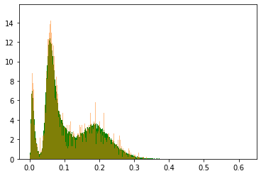

```python
np.random.seed(760303)
a10K_subset = np.random.choice(D, 10000)

plt.hist(D, bins=1000, facecolor='g', density=True)
plt.hist(a10K_subset, bins=1000, density=True, alpha=.5)
plt.show()
```

```python
t0 = time.time()

T = 1500
MH_samples, flag, accepts = run_a_MH_chain(a10K_subset, T, [0,0,1,-1,-1,-1,1e-3,1e-3,1e-3])

t1 = time.time()
total_time = t1 - t0
print('total time is', total_time//3600, 'hour', (total_time%3600)//60, 'minute', (total_time%3600)%60, 'seconds')
```

```
total time is 1.0 hour 0.0 minute 18.054951667785645 seconds
```

```python
sum(flag)/T
```

```
0.5986666666666667
```

```python
import csv

w = csv.writer(open("MH_samples.csv", "w"))

# loop over dictionary keys and values
for key, val in MH_samples.items():

    # write every key and value to file
    w.writerow([key, val])
```

```python
phi = np.array(MH_samples["phi"])
mu = np.array(MH_samples["mu"])
sigma = np.array(MH_samples["sigma"])
```

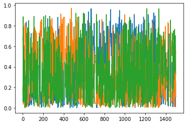

```python
plt.plot(phi[np.arange(1, phi.size, 3)])
plt.plot(phi[np.arange(2, phi.size, 3)])
plt.plot(phi[np.arange(3, phi.size, 3)])
```

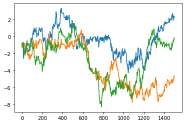

```python
plt.plot(mu[np.arange(1, mu.size, 3)])
plt.plot(mu[np.arange(2, mu.size, 3)])
plt.plot(mu[np.arange(3, mu.size, 3)])
```

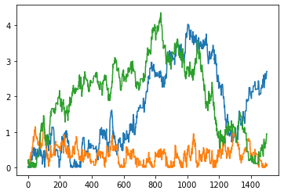

```python
plt.plot(sigma[np.arange(1, sigma.size, 3)])
plt.plot(sigma[np.arange(2, sigma.size, 3)])
plt.plot(sigma[np.arange(3, sigma.size, 3)])
```

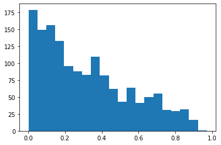

```python
plt.hist(phi[np.arange(2, sigma.size, 3)], bins=20)
```

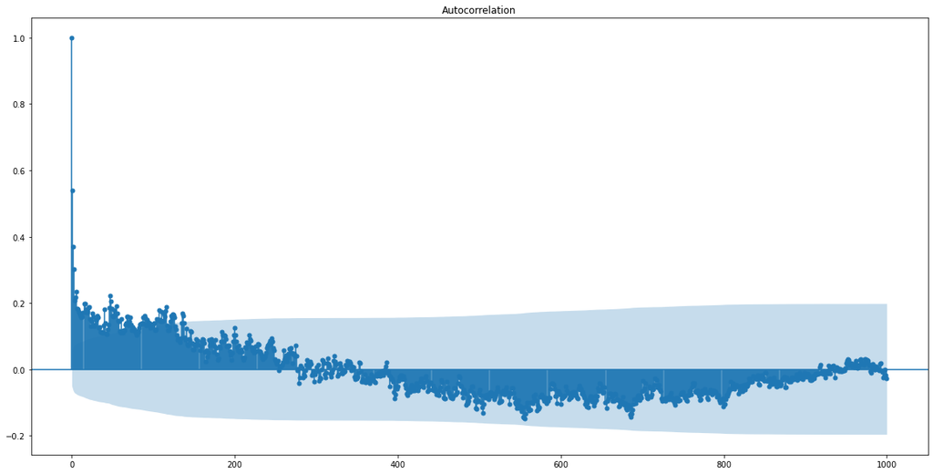

```python
plt.rc("figure", figsize=(20,10))
plt.figure(figsize=(20,10))
plot_acf(phi[np.arange(1, phi.size, 3)], lags=1000)
plt.show()
```

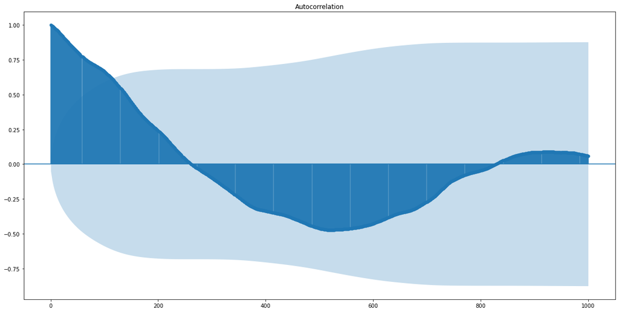

```python
plt.rc("figure", figsize=(20,10))
plt.figure(figsize=(20,10))
plot_acf(mu[np.arange(3, mu.size, 3)], lags=1000)
plt.show()
```

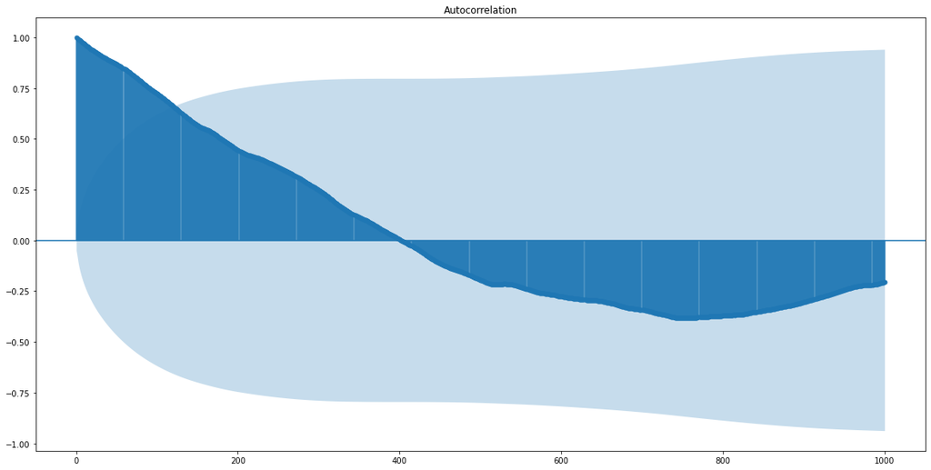

```python
plt.rc("figure", figsize=(20,10))
plt.figure(figsize=(20,10))
plot_acf(sigma[np.arange(1, sigma.size, 3)], lags=1000)
plt.show()
```

```python
phi_1 = phi[np.arange(3, phi.size, 3)]
len(phi_1)
```

```
1499
```

```python
phi_1_dec = phi_1[np.arange(1, len(phi_1), 10)]
len(phi_1_dec)
```

```
150
```

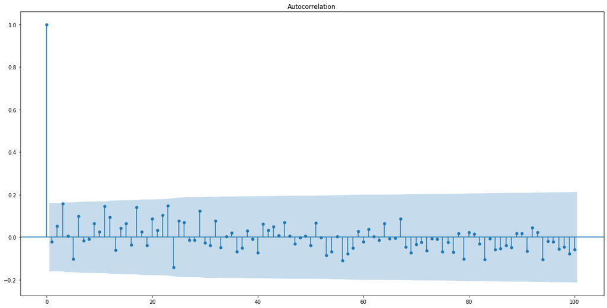

```python
plt.rc("figure", figsize=(20,10))
plt.figure(figsize=(20,10))
plot_acf(phi_1_dec, lags=100)
plt.show()
```

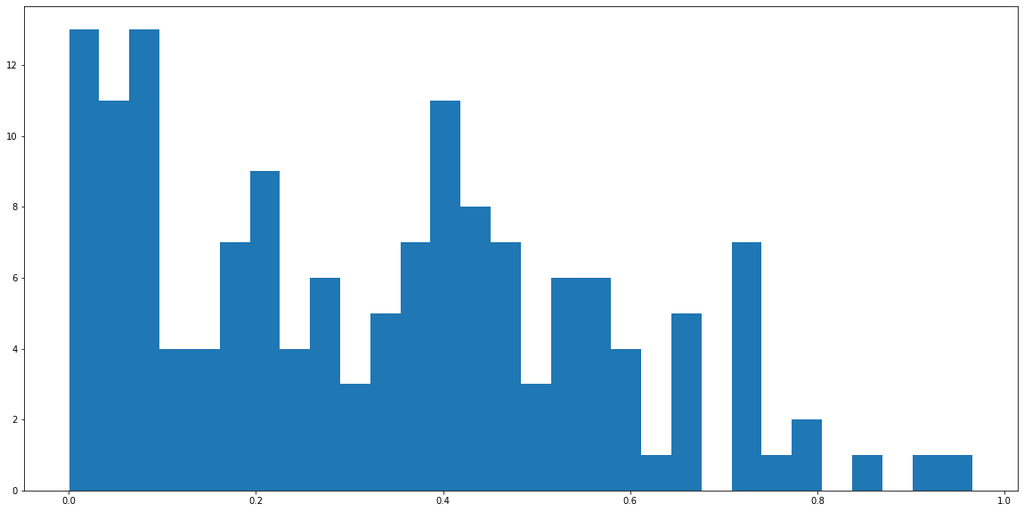

```python
plt.hist(phi_1_dec, bins=30)
```